# Risk Factor Analysis

## Outcome Variable

**Outcome Variable:** whz

## Predictor Variables

**Intervention Variable:** nchldlt5

**Adjustment Set:**

- arm
- W_mage
- meducyrs
- feducyrs
- hhwealth_quart
- hfoodsec
- W_mhtcm
- W_mwtkg
- W_mbmi
- W_nrooms
- W_parity
- impfloor
- impsan
- safeh20
- delta_W_mage
- delta_meducyrs
- delta_feducyrs
- delta_hhwealth_quart
- delta_hfoodsec
- delta_W_mhtcm
- delta_W_mwtkg
- delta_W_mbmi
- delta_W_nrooms
- delta_W_parity
- delta_impfloor
- delta_impsan
- delta_safeh20

## Stratifying Variables

The analysis was stratified on these variable(s):

- agecat
- studyid
- country

## Data Summary

| agecat | studyid | country | nchldlt5 | n_cell | n | outcome_variable |
| --- | --- | --- | --- | --- | --- | --- |
| Birth | IRC | INDIA | 1 | 72 | 343 | whz |
| Birth | IRC | INDIA | 2+ | 271 | 343 | whz |
| Birth | JiVitA-3 | BANGLADESH | 1 | 10878 | 17991 | whz |
| Birth | JiVitA-3 | BANGLADESH | 2+ | 7113 | 17991 | whz |
| Birth | NIH-Crypto | BANGLADESH | 1 | 504 | 707 | whz |
| Birth | NIH-Crypto | BANGLADESH | 2+ | 203 | 707 | whz |
| Birth | PROVIDE | BANGLADESH | 1 | 385 | 532 | whz |
| Birth | PROVIDE | BANGLADESH | 2+ | 147 | 532 | whz |
| 6 months | IRC | INDIA | 1 | 88 | 408 | whz |
| 6 months | IRC | INDIA | 2+ | 320 | 408 | whz |
| 6 months | JiVitA-3 | BANGLADESH | 1 | 10872 | 16773 | whz |
| 6 months | JiVitA-3 | BANGLADESH | 2+ | 5901 | 16773 | whz |
| 6 months | LCNI-5 | MALAWI | 1 | 390 | 811 | whz |
| 6 months | LCNI-5 | MALAWI | 2+ | 421 | 811 | whz |
| 6 months | NIH-Crypto | BANGLADESH | 1 | 507 | 715 | whz |
| 6 months | NIH-Crypto | BANGLADESH | 2+ | 208 | 715 | whz |
| 6 months | PROVIDE | BANGLADESH | 1 | 438 | 603 | whz |
| 6 months | PROVIDE | BANGLADESH | 2+ | 165 | 603 | whz |
| 6 months | TanzaniaChild2 | TANZANIA, UNITED REPUBLIC OF | 1 | 1390 | 2019 | whz |
| 6 months | TanzaniaChild2 | TANZANIA, UNITED REPUBLIC OF | 2+ | 629 | 2019 | whz |
| 24 months | IRC | INDIA | 1 | 89 | 409 | whz |
| 24 months | IRC | INDIA | 2+ | 320 | 409 | whz |
| 24 months | JiVitA-3 | BANGLADESH | 1 | 5434 | 8593 | whz |
| 24 months | JiVitA-3 | BANGLADESH | 2+ | 3159 | 8593 | whz |
| 24 months | LCNI-5 | MALAWI | 1 | 277 | 555 | whz |
| 24 months | LCNI-5 | MALAWI | 2+ | 278 | 555 | whz |
| 24 months | NIH-Crypto | BANGLADESH | 1 | 357 | 514 | whz |
| 24 months | NIH-Crypto | BANGLADESH | 2+ | 157 | 514 | whz |
| 24 months | PROVIDE | BANGLADESH | 1 | 424 | 579 | whz |
| 24 months | PROVIDE | BANGLADESH | 2+ | 155 | 579 | whz |
| 24 months | TanzaniaChild2 | TANZANIA, UNITED REPUBLIC OF | 1 | 5 | 6 | whz |
| 24 months | TanzaniaChild2 | TANZANIA, UNITED REPUBLIC OF | 2+ | 1 | 6 | whz |

The following strata were considered:

- agecat: 24 months, studyid: IRC, country: INDIA
- agecat: 24 months, studyid: JiVitA-3, country: BANGLADESH
- agecat: 24 months, studyid: LCNI-5, country: MALAWI
- agecat: 24 months, studyid: NIH-Crypto, country: BANGLADESH
- agecat: 24 months, studyid: PROVIDE, country: BANGLADESH
- agecat: 24 months, studyid: TanzaniaChild2, country: TANZANIA, UNITED REPUBLIC OF
- agecat: 6 months, studyid: IRC, country: INDIA
- agecat: 6 months, studyid: JiVitA-3, country: BANGLADESH
- agecat: 6 months, studyid: LCNI-5, country: MALAWI
- agecat: 6 months, studyid: NIH-Crypto, country: BANGLADESH
- agecat: 6 months, studyid: PROVIDE, country: BANGLADESH
- agecat: 6 months, studyid: TanzaniaChild2, country: TANZANIA, UNITED REPUBLIC OF
- agecat: Birth, studyid: IRC, country: INDIA
- agecat: Birth, studyid: JiVitA-3, country: BANGLADESH
- agecat: Birth, studyid: NIH-Crypto, country: BANGLADESH
- agecat: Birth, studyid: PROVIDE, country: BANGLADESH

### Dropped Strata

Some strata were dropped due to rare outcomes:

- agecat: 24 months, studyid: TanzaniaChild2, country: TANZANIA, UNITED REPUBLIC OF

## Methods Detail

We’re interested in the causal parameters $E[Y_a]$ for all values of $a \in \mathcal{A}$. These parameters represent the mean outcome if, possibly contrary to fact, we intervened to set all units to have $A=a$. Under the randomization and positivity assumptions, these are identified by the statistical parameters $\psi_a=E_W[E_{Y|A,W}(Y|A=a,W)]$. In addition, we’re interested in the mean of $Y$, $E[Y]$ under no intervention (the observed mean). We will estimate these parameters by using SuperLearner to fit the relevant likelihood factors – $E_{Y|A,W}(Y|A=a,W)$ and $p(A=a|W)$, and then updating our likelihood fit using a joint TMLE.

For unadjusted analyses ($W=\{\}$), initial likelihoods were estimated using Lrnr_glm to estimate the simple $E(Y|A)$ and Lrnr_mean to estimate $p(A)$. For adjusted analyses, a small library containing Lrnr_glmnet, Lrnr_xgboost, and Lrnr_mean was used.

Having estimated these parameters, we will then use the delta method to estimate relative risks and attributable risks relative to a prespecified baseline level of $A$.

# Results Detail

## Results Plots

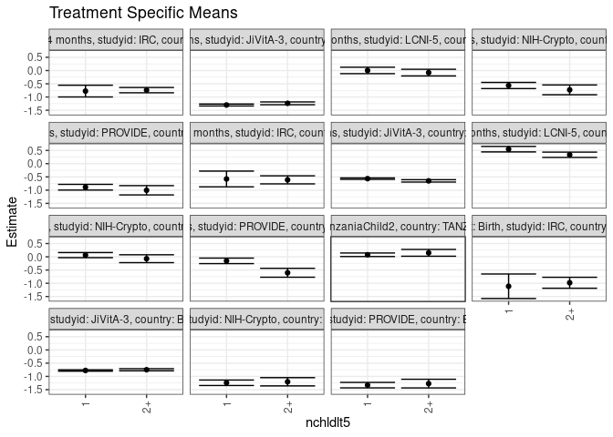

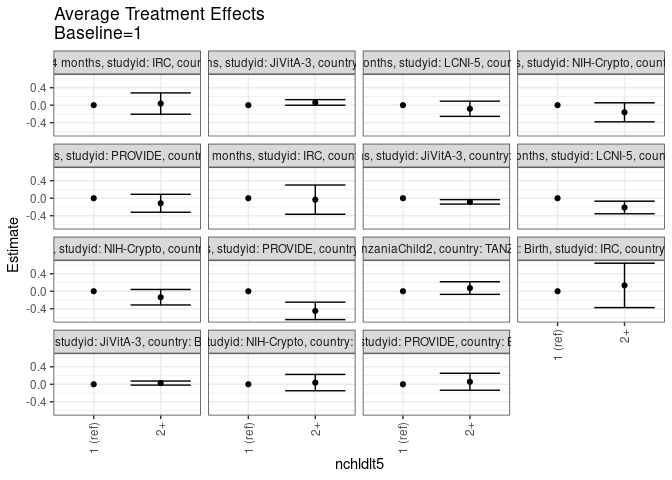

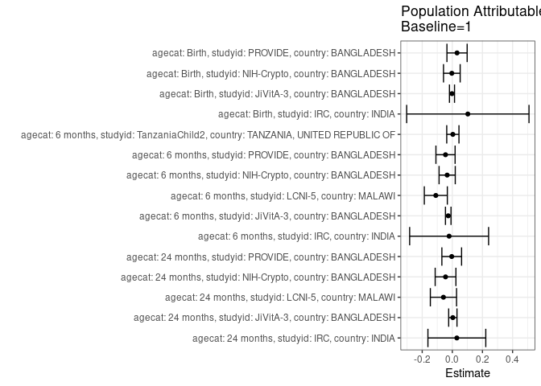

## Results Table

### Parameter: TSM

| agecat | studyid | country | intervention_level | baseline_level | estimate | ci_lower | ci_upper |
| --- | --- | --- | --- | --- | --- | --- | --- |
| Birth | IRC | INDIA | 1 | NA | -1.1135099 | -1.5768202 | -0.6501996 |
| Birth | IRC | INDIA | 2+ | NA | -0.9801344 | -1.1872337 | -0.7730350 |
| Birth | JiVitA-3 | BANGLADESH | 1 | NA | -0.7754562 | -0.8016291 | -0.7492833 |
| Birth | JiVitA-3 | BANGLADESH | 2+ | NA | -0.7479942 | -0.7879194 | -0.7080690 |
| Birth | NIH-Crypto | BANGLADESH | 1 | NA | -1.2408792 | -1.3440070 | -1.1377513 |
| Birth | NIH-Crypto | BANGLADESH | 2+ | NA | -1.2024289 | -1.3581165 | -1.0467413 |
| Birth | PROVIDE | BANGLADESH | 1 | NA | -1.3297981 | -1.4328459 | -1.2267503 |
| Birth | PROVIDE | BANGLADESH | 2+ | NA | -1.2717604 | -1.4357938 | -1.1077271 |
| 6 months | IRC | INDIA | 1 | NA | -0.5776610 | -0.8748926 | -0.2804293 |
| 6 months | IRC | INDIA | 2+ | NA | -0.6105304 | -0.7623887 | -0.4586722 |
| 6 months | JiVitA-3 | BANGLADESH | 1 | NA | -0.5660898 | -0.5932701 | -0.5389096 |
| 6 months | JiVitA-3 | BANGLADESH | 2+ | NA | -0.6494724 | -0.6939191 | -0.6050258 |
| 6 months | LCNI-5 | MALAWI | 1 | NA | 0.5475572 | 0.4439551 | 0.6511593 |
| 6 months | LCNI-5 | MALAWI | 2+ | NA | 0.3354020 | 0.2355835 | 0.4352204 |
| 6 months | NIH-Crypto | BANGLADESH | 1 | NA | 0.0640700 | -0.0320378 | 0.1601777 |
| 6 months | NIH-Crypto | BANGLADESH | 2+ | NA | -0.0724312 | -0.2218025 | 0.0769401 |
| 6 months | PROVIDE | BANGLADESH | 1 | NA | -0.1538342 | -0.2581980 | -0.0494705 |
| 6 months | PROVIDE | BANGLADESH | 2+ | NA | -0.6028070 | -0.7717229 | -0.4338911 |
| 6 months | TanzaniaChild2 | TANZANIA, UNITED REPUBLIC OF | 1 | NA | 0.0767121 | 0.0105353 | 0.1428890 |
| 6 months | TanzaniaChild2 | TANZANIA, UNITED REPUBLIC OF | 2+ | NA | 0.1496567 | 0.0212992 | 0.2780141 |
| 24 months | IRC | INDIA | 1 | NA | -0.7758554 | -0.9979327 | -0.5537781 |
| 24 months | IRC | INDIA | 2+ | NA | -0.7394571 | -0.8394887 | -0.6394255 |
| 24 months | JiVitA-3 | BANGLADESH | 1 | NA | -1.3006439 | -1.3369479 | -1.2643398 |
| 24 months | JiVitA-3 | BANGLADESH | 2+ | NA | -1.2379544 | -1.2913408 | -1.1845681 |
| 24 months | LCNI-5 | MALAWI | 1 | NA | 0.0042109 | -0.1172222 | 0.1256440 |
| 24 months | LCNI-5 | MALAWI | 2+ | NA | -0.0781524 | -0.2032993 | 0.0469944 |
| 24 months | NIH-Crypto | BANGLADESH | 1 | NA | -0.5653568 | -0.6817676 | -0.4489460 |
| 24 months | NIH-Crypto | BANGLADESH | 2+ | NA | -0.7290069 | -0.9138934 | -0.5441203 |
| 24 months | PROVIDE | BANGLADESH | 1 | NA | -0.8888810 | -0.9968729 | -0.7808892 |
| 24 months | PROVIDE | BANGLADESH | 2+ | NA | -1.0044147 | -1.1794252 | -0.8294042 |

### Parameter: E(Y)

| agecat | studyid | country | intervention_level | baseline_level | estimate | ci_lower | ci_upper |
| --- | --- | --- | --- | --- | --- | --- | --- |
| Birth | IRC | INDIA | NA | NA | -1.0105831 | -1.1973019 | -0.8238643 |
| Birth | JiVitA-3 | BANGLADESH | NA | NA | -0.7776666 | -0.7966629 | -0.7586703 |
| Birth | NIH-Crypto | BANGLADESH | NA | NA | -1.2441513 | -1.3281130 | -1.1601897 |
| Birth | PROVIDE | BANGLADESH | NA | NA | -1.2984586 | -1.3752758 | -1.2216415 |
| 6 months | IRC | INDIA | NA | NA | -0.5989297 | -0.7344491 | -0.4634104 |
| 6 months | JiVitA-3 | BANGLADESH | NA | NA | -0.5932472 | -0.6127728 | -0.5737215 |
| 6 months | LCNI-5 | MALAWI | NA | NA | 0.4379655 | 0.3664533 | 0.5094777 |
| 6 months | NIH-Crypto | BANGLADESH | NA | NA | 0.0297622 | -0.0491685 | 0.1086930 |
| 6 months | PROVIDE | BANGLADESH | NA | NA | -0.1990907 | -0.2817968 | -0.1163845 |
| 6 months | TanzaniaChild2 | TANZANIA, UNITED REPUBLIC OF | NA | NA | 0.0801680 | 0.0273223 | 0.1330136 |
| 24 months | IRC | INDIA | NA | NA | -0.7458150 | -0.8368180 | -0.6548120 |
| 24 months | JiVitA-3 | BANGLADESH | NA | NA | -1.2972908 | -1.3206179 | -1.2739638 |
| 24 months | LCNI-5 | MALAWI | NA | NA | -0.0547297 | -0.1370054 | 0.0275459 |
| 24 months | NIH-Crypto | BANGLADESH | NA | NA | -0.6103502 | -0.7050157 | -0.5156847 |
| 24 months | PROVIDE | BANGLADESH | NA | NA | -0.8928670 | -0.9755153 | -0.8102187 |

### Parameter: ATE

| agecat | studyid | country | intervention_level | baseline_level | estimate | ci_lower | ci_upper |
| --- | --- | --- | --- | --- | --- | --- | --- |
| Birth | IRC | INDIA | 1 | 1 | 0.0000000 | 0.0000000 | 0.0000000 |
| Birth | IRC | INDIA | 2+ | 1 | 0.1333755 | -0.3739381 | 0.6406891 |
| Birth | JiVitA-3 | BANGLADESH | 1 | 1 | 0.0000000 | 0.0000000 | 0.0000000 |
| Birth | JiVitA-3 | BANGLADESH | 2+ | 1 | 0.0274620 | -0.0191864 | 0.0741103 |
| Birth | NIH-Crypto | BANGLADESH | 1 | 1 | 0.0000000 | 0.0000000 | 0.0000000 |
| Birth | NIH-Crypto | BANGLADESH | 2+ | 1 | 0.0384502 | -0.1484521 | 0.2253526 |
| Birth | PROVIDE | BANGLADESH | 1 | 1 | 0.0000000 | 0.0000000 | 0.0000000 |
| Birth | PROVIDE | BANGLADESH | 2+ | 1 | 0.0580376 | -0.1357906 | 0.2518658 |
| 6 months | IRC | INDIA | 1 | 1 | 0.0000000 | 0.0000000 | 0.0000000 |
| 6 months | IRC | INDIA | 2+ | 1 | -0.0328695 | -0.3667795 | 0.3010406 |
| 6 months | JiVitA-3 | BANGLADESH | 1 | 1 | 0.0000000 | 0.0000000 | 0.0000000 |
| 6 months | JiVitA-3 | BANGLADESH | 2+ | 1 | -0.0833826 | -0.1346176 | -0.0321476 |
| 6 months | LCNI-5 | MALAWI | 1 | 1 | 0.0000000 | 0.0000000 | 0.0000000 |
| 6 months | LCNI-5 | MALAWI | 2+ | 1 | -0.2121552 | -0.3558704 | -0.0684401 |
| 6 months | NIH-Crypto | BANGLADESH | 1 | 1 | 0.0000000 | 0.0000000 | 0.0000000 |
| 6 months | NIH-Crypto | BANGLADESH | 2+ | 1 | -0.1365012 | -0.3136577 | 0.0406553 |
| 6 months | PROVIDE | BANGLADESH | 1 | 1 | 0.0000000 | 0.0000000 | 0.0000000 |
| 6 months | PROVIDE | BANGLADESH | 2+ | 1 | -0.4489728 | -0.6480976 | -0.2498479 |
| 6 months | TanzaniaChild2 | TANZANIA, UNITED REPUBLIC OF | 1 | 1 | 0.0000000 | 0.0000000 | 0.0000000 |
| 6 months | TanzaniaChild2 | TANZANIA, UNITED REPUBLIC OF | 2+ | 1 | 0.0729446 | -0.0716820 | 0.2175711 |
| 24 months | IRC | INDIA | 1 | 1 | 0.0000000 | 0.0000000 | 0.0000000 |
| 24 months | IRC | INDIA | 2+ | 1 | 0.0363983 | -0.2074056 | 0.2802022 |
| 24 months | JiVitA-3 | BANGLADESH | 1 | 1 | 0.0000000 | 0.0000000 | 0.0000000 |
| 24 months | JiVitA-3 | BANGLADESH | 2+ | 1 | 0.0626894 | -0.0011364 | 0.1265153 |
| 24 months | LCNI-5 | MALAWI | 1 | 1 | 0.0000000 | 0.0000000 | 0.0000000 |
| 24 months | LCNI-5 | MALAWI | 2+ | 1 | -0.0823633 | -0.2561898 | 0.0914632 |
| 24 months | NIH-Crypto | BANGLADESH | 1 | 1 | 0.0000000 | 0.0000000 | 0.0000000 |
| 24 months | NIH-Crypto | BANGLADESH | 2+ | 1 | -0.1636501 | -0.3813292 | 0.0540290 |
| 24 months | PROVIDE | BANGLADESH | 1 | 1 | 0.0000000 | 0.0000000 | 0.0000000 |
| 24 months | PROVIDE | BANGLADESH | 2+ | 1 | -0.1155336 | -0.3206350 | 0.0895677 |

### Parameter: PAR

| agecat | studyid | country | intervention_level | baseline_level | estimate | ci_lower | ci_upper |
| --- | --- | --- | --- | --- | --- | --- | --- |
| Birth | IRC | INDIA | 1 | NA | 0.1029268 | -0.3031859 | 0.5090395 |
| Birth | JiVitA-3 | BANGLADESH | 1 | NA | -0.0022104 | -0.0189801 | 0.0145593 |
| Birth | NIH-Crypto | BANGLADESH | 1 | NA | -0.0032722 | -0.0586211 | 0.0520767 |
| Birth | PROVIDE | BANGLADESH | 1 | NA | 0.0313394 | -0.0357837 | 0.0984625 |
| 6 months | IRC | INDIA | 1 | NA | -0.0212688 | -0.2833803 | 0.2408428 |
| 6 months | JiVitA-3 | BANGLADESH | 1 | NA | -0.0271574 | -0.0455382 | -0.0087765 |
| 6 months | LCNI-5 | MALAWI | 1 | NA | -0.1095918 | -0.1860009 | -0.0331826 |
| 6 months | NIH-Crypto | BANGLADESH | 1 | NA | -0.0343077 | -0.0880136 | 0.0193981 |
| 6 months | PROVIDE | BANGLADESH | 1 | NA | -0.0452564 | -0.1089373 | 0.0184244 |
| 6 months | TanzaniaChild2 | TANZANIA, UNITED REPUBLIC OF | 1 | NA | 0.0034559 | -0.0371278 | 0.0440396 |
| 24 months | IRC | INDIA | 1 | NA | 0.0300404 | -0.1620272 | 0.2221080 |
| 24 months | JiVitA-3 | BANGLADESH | 1 | NA | 0.0033531 | -0.0241770 | 0.0308832 |
| 24 months | LCNI-5 | MALAWI | 1 | NA | -0.0589406 | -0.1459425 | 0.0280613 |
| 24 months | NIH-Crypto | BANGLADESH | 1 | NA | -0.0449934 | -0.1138503 | 0.0238635 |
| 24 months | PROVIDE | BANGLADESH | 1 | NA | -0.0039860 | -0.0694025 | 0.0614306 |